# hunting-2-variable-dynamic

Author

Kyle Burt, Michelle Moreno

# Hunting Two-Variable Dynamic Assignment

In this assignment, we extend a classical predator-prey model to include conditional hunting/harvesting (in our model we use, synonymous term, “hunting”). The goal is to examine how different hunting intensities and rules (e.g., only hunt when prey exceed a certain threshold) affect the long-term stability of the ecosystem. This approach helps identify sustainable harvesting strategies that protect both predator and prey populations over time.

The predator-prey model is adapted from “Rapid and direct recoveries of predators and prey through synchronized ecosystem management” by Jameal F. Samhouri, Adrian C. Stier, Shannon M. Hennessey, Mark Novak, Benjamin S. Halpern, and Phillip S. Levin (2017).

# Load Libraries

## Source the function

```r
source("hunting-lotvmod.R")
```

Here we set up the Base Parameters. Built model called hunting-lotmod.R by adding hunting/harvesting to the lotvmodK.R. We dded a conditional harvest (min_harvest_X) and min(hX * X, X) to make sure we do not over-harvest.

```r
hX_vals <- seq(0, 0.2, by = 0.02)
min_harvest_X_vals <- seq(100, 800, by = 100)
grid <- expand.grid(hX = hX_vals, min_harvest_X = min_harvest_X_vals)
```

```r
# Fixed parameters
params_base <- list(
  rX = 0.95, KX = 2000, aX = 0.01, aY = 0.005, c = 0.6,
  dP = 0.4, KP = 500, hP = 0, Y = 1000
)

# Initial state
state <- c(X = 1000, P = 100)

# Time vector
times <- seq(0, 50, by = 1)
```

## Results for each parameter

```r
results <- pmap_dfr(grid, function(hX, min_harvest_X) {
  parms <- c(params_base, hX = hX, min_harvest_X = min_harvest_X)
  out <- ode(y = state, times = times, func = complex_pred_prey,
             parms = parms)
  out_df <- as.data.frame(out)

  # Clean up: cap negative populations at zero
  out_df$X <- pmax(out_df$X, 0)
  out_df$P <- pmax(out_df$P, 0)

  final_X <- tail(out_df$X, 1)
  final_P <- tail(out_df$P, 1)

  tibble(hX, min_harvest_X,
         final_X, final_P,
         stable = (final_X > 50) & (final_P > 50))
})
```

A simulation was considered stable if both prey and predator populations remained above 50 individuals at the end of 50 years. This metric was chosen because it is biologically meaningful and easily interpreted. It is biologically meaningful because populations below 50 individuals are at high risk of extinction due to demographic or environmental stochasticity. It is simple and easily interpreted, which allows for clear comparisons across harvesting strategies. This threshold approach avoids false confidence in highly fluctuating but non-zero population dynamics and provides a conservative estimate of sustainability.

## Data Visualization

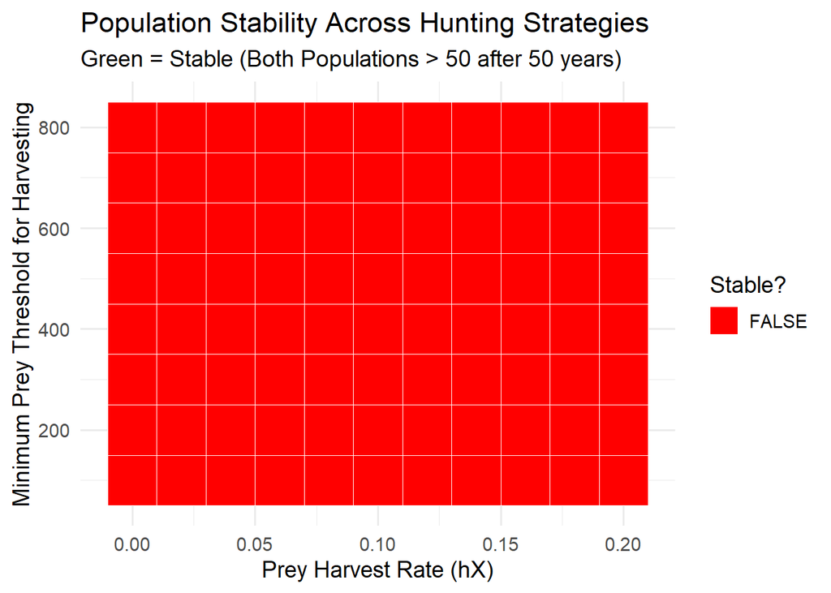

```r
ggplot(results, aes(x = hX, y = min_harvest_X, fill = stable)) +
  geom_tile(color = "white") +
  scale_fill_manual(values = c("TRUE" = "darkgreen", "FALSE" = "red")) +
  labs(title = "Population Stability Across Hunting Strategies",
    subtitle = "Green = Stable (Both Populations > 50 after 50 years)",
    x = "Prey Harvest Rate (hX)",
    y = "Minimum Prey Threshold for Harvesting",
    fill = "Stable?") +
  theme_minimal(base_size = 14)
```

## Checking population values

```r
summary(results$final_X)
```

```
   Min. 1st Qu.  Median    Mean 3rd Qu.    Max.
      0       0       0       0       0       0
```

```r
summary(results$final_P)
```

```
   Min. 1st Qu.  Median    Mean 3rd Qu.    Max.
    500     500     500     500     500     500
```